# 1. Import necessary dependencies

```python
# libraries & dataset
import seaborn as sns
import matplotlib.pyplot as plt

sns.set_theme(style="darkgrid")
```

# 2. Import the required dataset

```python
df = sns.load_dataset("iris")
```

```python
df.head()
```

|  | sepal_length | sepal_width | petal_length | petal_width | species |
| --- | --- | --- | --- | --- | --- |
| 0 | 5.1 | 3.5 | 1.4 | 0.2 | setosa |
| 1 | 4.9 | 3.0 | 1.4 | 0.2 | setosa |
| 2 | 4.7 | 3.2 | 1.3 | 0.2 | setosa |
| 3 | 4.6 | 3.1 | 1.5 | 0.2 | setosa |
| 4 | 5.0 | 3.6 | 1.4 | 0.2 | setosa |

# 3. Visualize different columns

### A. Drawing a simple histogram with default parameters

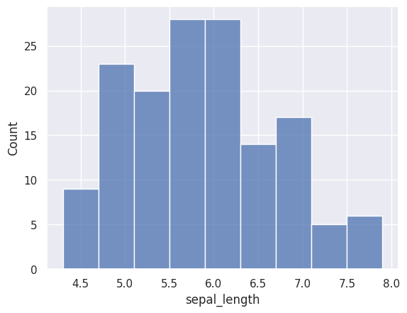

```python
sns.histplot(data=df, x="sepal_length")
plt.show()
```

### B. Controlling for the number of Bins

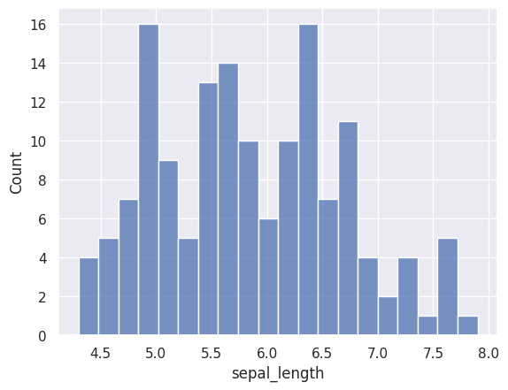

```python
sns.histplot(data=df, x="sepal_length", bins=20)
plt.show()
```

### C. Improving the graph with different parameters

- Specify the data and the x-variable.
- Set the color of the bars.
- Add a label for the legend.
- Include a KDE curve.
- Set the bin width.
- Adjust the transparency.
- Change the y-axis to density.
- Add a title and axis labels.
- Show the legend.

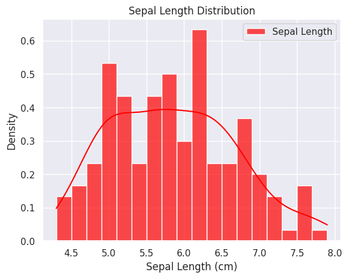

```python
sns.histplot(
    data=df,
    x="sepal_length",
    color="red",
    label="Sepal Length",
    kde=True,
    binwidth=0.2,
    alpha=0.7,
    stat="density"
)
plt.title("Sepal Length Distribution")
plt.xlabel("Sepal Length (cm)")
plt.ylabel("Density")
plt.legend()
plt.show()
```

### D. Visualize multiple histograms together

1. Define the columns to plot ( update based on your scenario )
2. Define the colors of each histogram ( update based on your choice/preference )
3. we created a 2 * 2 matrix with each figure as (14 , 10 ) , you can update each of them based on preference

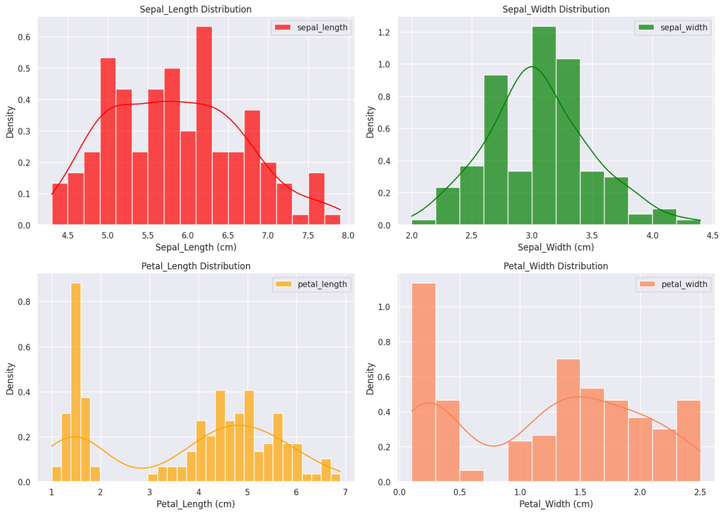

```python
# Define the columns to plot
columns_to_plot = ['sepal_length', 'sepal_width', 'petal_length', 'petal_width']

# Define colors for each histogram
colors = ['red', 'green', 'orange', 'coral']  # Add more colors if needed

# Create a 2x2 subplot grid with a fixed figure size
fig, axes = plt.subplots(2, 2, figsize=(14, 10))

# Iterate through the columns and plot each one in a separate subplot
for i, col in enumerate(columns_to_plot):
    # Determine the row and column for the current subplot
    row = i // 2
    col_num = i % 2

    # Select the appropriate subplot axis
    ax = axes[row, col_num]

    # Create the histogram with KDE, using a different color for each
    sns.histplot(data=df, x=col, color=colors[i], label=col, kde=True, binwidth=0.2, alpha=0.7, stat="density", ax=ax)

    # Set the title and labels for the subplot
    ax.set_title(f"{col.title()} Distribution")
    ax.set_xlabel(f"{col.title()} (cm)")
    ax.set_ylabel("Density")
    ax.legend()

# Adjust the layout to prevent overlapping titles/labels
plt.tight_layout()

# Display the plots
plt.show()
```